# Profile

Karsten T. Maurer

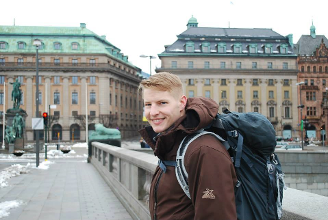

## Who am I?

My name is Karsten Maurer. I am originally from the Twin Cities area of Minnesota. I am currently an assistant professor of statistics at Miami University in Oxford, Ohio. I completed my doctoral degree in statistics at Iowa State University. My research interests are in the fields of statistics education and statistical graphics.

## Documents

**Curriculum Vitae**

**Teaching Philosophy**

**Research Statement**

## Publications

*[Comparison of Learning Outcomes for Randomization-Based and Traditional Inference Curricula in a Designed Educational Experiment](http://escholarship.org/uc/item/0wm523b0)*

*[Examining the Effect of Proctoring on Online Test Scores](https://olj.onlinelearningconsortium.org/index.php/olj/article/view/885)*

*Self Selection Does Not Increase Other-Regarding Preferences among Adult Laboratory Subjects, but Student Subjects May Be More Self-Regarding than Adults*

## Submitted Manuscripts

*Tale of Four Cities: Exploring the Soul of State College, Detroit, Millidgeville and Biloxi* (submitted to COST 06/13/14)

## Hobbies

- Rock Climbing
- Ultimate Frisbee
- Camping
- Hiking
- Wood Carving
- Vegetable Gardening

## Data Science Night Slides and Code

**DataWrangling.html**

**ggplot2Intro.pdf**

**ggplot2Intro.R**

## Quick Data Host

**pitching_careers.csv**

**Pitching2014.csv**

**batting.Rdata**

**DelaysDec2014.Rdata**

**nycCabsSample2014Dec.Rdata**

**OhioBRFSS2015.csv**

**StateCountyFIPS.csv**

**OhioWeatherStations2013.csv**

**pitchingSample.csv**

**Airfares.csv**

**StateStatsBRFSS.csv**

**StateStatsBRFSSMessy.csv**

**nasadata.csv**

**baseball.csv**

**SLahman_Batting2014.csv**